# Shooting Incident Trends in New York

RB

2025-06-16

## Dataset overview

This analysis examines the data from **NYPD Shooting Incident Data (Historic)**, which is provided by the New York City Police Department (NYPD). You can access the data from [Data.gov](https://catalog.data.gov/dataset/nypd-shooting-incident-data-historic). The analysis will focus on incident patterns regarding victim demographics and temporal patterns.

## Key Concepts

1. Importing and cleaning data
2. Demographic analysis - identifying victim age and gender distributions
3. Temporal patterns - identifying day-of-week effects and forecasting trends.
4. Statistical testing - Using ANOVA to confirm statistical significance.

## Data Overview

The Data from **NYPD Shooting Incident Data (Historic)** includes incident timing, location, and demographic information for victims and perpetrators.

### Research Questions

1. What are the demographics of victims
- By gender
- By age group
2. Do incidents occurring follow a pattern based on day of the week or month?

## Step 1: Importing the raw data.

This data is hosted as a csv file on NYC open data

```r
#libraries needed
library(tidyverse)
library(janitor)
library(lubridate)
library(ggplot2)

#First, lets import the data
url = "https://data.cityofnewyork.us/api/views/833y-fsy8/rows.csv?accessType=DOWNLOAD"
shooting_data = read_csv(url)
```

```r
# Preview the data
head(shooting_data)
```

```
## # A tibble: 6 × 21
##   INCIDENT_KEY OCCUR_DATE OCCUR_TIME BORO     LOC_OF_OCCUR_DESC PRECINCT
##          <dbl> <chr>      <time>     <chr>    <chr>                <dbl>
## 1    231974218 08/09/2021 01:06      BRONX    <NA>                    40
## 2    177934247 04/07/2018 19:48      BROOKLYN <NA>                    79
## 3    255028563 12/02/2022 22:57      BRONX    OUTSIDE                 47
## 4     25384540 11/19/2006 01:50      BROOKLYN <NA>                    66
## 5     72616285 05/09/2010 01:58      BRONX    <NA>                    46
## 6     85875439 07/22/2012 21:35      BRONX    <NA>                    42
## # ℹ 15 more variables: JURISDICTION_CODE <dbl>, LOC_CLASSFCTN_DESC <chr>,
## #   LOCATION_DESC <chr>, STATISTICAL_MURDER_FLAG <lgl>, PERP_AGE_GROUP <chr>,
## #   PERP_SEX <chr>, PERP_RACE <chr>, VIC_AGE_GROUP <chr>, VIC_SEX <chr>,
## #   VIC_RACE <chr>, X_COORD_CD <dbl>, Y_COORD_CD <dbl>, Latitude <dbl>,
## #   Longitude <dbl>, Lon_Lat <chr>
```

## Step 2: **Cleaning** the data (making it tidy)

We’ll standardize column names, convert dates to proper formatting, and select relevant variables.

```r
# column names to all lower case
cleaned_data = shooting_data %>%
      clean_names()

# convert date from string to data using lubridate
cleaned_data <- cleaned_data %>%
  mutate(occur_date = mdy(occur_date))

# select columns of interest only
selected_data <- cleaned_data %>%
  select(
    occur_date,
    boro,
    vic_age_group,
    vic_sex,
    vic_race,
    perp_age_group,
    perp_sex,
    perp_race,
    statistical_murder_flag
  )

# add time and day columns
selected_data <- selected_data %>%
  mutate(
    year = year(occur_date),
    day_of_week = wday(occur_date, label = TRUE)
  )

# preview data
head(selected_data)
```

```
## # A tibble: 6 × 11
##   occur_date boro     vic_age_group vic_sex vic_race perp_age_group perp_sex
##   <date>     <chr>    <chr>         <chr>   <chr>    <chr>          <chr>
## 1 2021-08-09 BRONX    18-24         M       BLACK    <NA>           <NA>
## 2 2018-04-07 BROOKLYN 25-44         M       BLACK    25-44          M
## 3 2022-12-02 BRONX    25-44         M       BLACK    (null)         (null)
## 4 2006-11-19 BROOKLYN 18-24         M       BLACK    UNKNOWN        U
## 5 2010-05-09 BRONX    <18           F       BLACK    25-44          M
## 6 2012-07-22 BRONX    18-24         M       BLACK    18-24          M
## # ℹ 4 more variables: perp_race <chr>, statistical_murder_flag <lgl>,
## #   year <dbl>, day_of_week <ord>
```

## Step 3: Victim Demoghraphics

### Data Quality Check

**Checking** data for duplicates, unique , or missing information.

```r
# select columns of interest
victim_demo <- cleaned_data %>%
  select(vic_age_group, vic_sex)

# unique characters in age & gender
unique(victim_demo$vic_age_group)
```

```
## [1] "18-24"   "25-44"   "<18"     "45-64"   "65+"     "UNKNOWN" "1022"
```

```r
unique(victim_demo$vic_sex)
```

```
## [1] "M" "F" "U"
```

### Distribution of Categories

lets **check on the counts** of each of those found unique charcaters.

```r
# Count full distribution of age groups
cleaned_data %>%
  count(vic_age_group) %>%
  arrange(desc(n))
```

```
## # A tibble: 7 × 2
##   vic_age_group     n
##   <chr>         <int>
## 1 25-44         13563
## 2 18-24         10677
## 3 <18            3081
## 4 45-64          2118
## 5 65+             236
## 6 UNKNOWN          68
## 7 1022              1
```

```r
# Count full distribution of sex
cleaned_data %>%
  count(vic_sex) %>%
  arrange(desc(n))
```

```
## # A tibble: 3 × 2
##   vic_sex     n
##   <chr>   <int>
## 1 M       26841
## 2 F        2891
## 3 U          12
```

### Clean Demographic data

**remove the unknown** data: As shown above, there are multiple unknowns and 1 typo.

```r
# Filter and clean victim demographic data for plotting
victim_filtered_data <- cleaned_data %>%
  filter(
    vic_age_group %in% c("<18", "18-24", "25-44", "45-64", "65+"),
    vic_sex %in% c("M", "F")
  ) %>%
  select(vic_age_group, vic_sex)
# Check your work
head(victim_filtered_data)
```

```
## # A tibble: 6 × 2
##   vic_age_group vic_sex
##   <chr>         <chr>
## 1 18-24         M
## 2 25-44         M
## 3 25-44         M
## 4 18-24         M
## 5 <18           F
## 6 18-24         M
```

### Age Group Distribution

**Bar graph** to show the distribution of victim age groups.

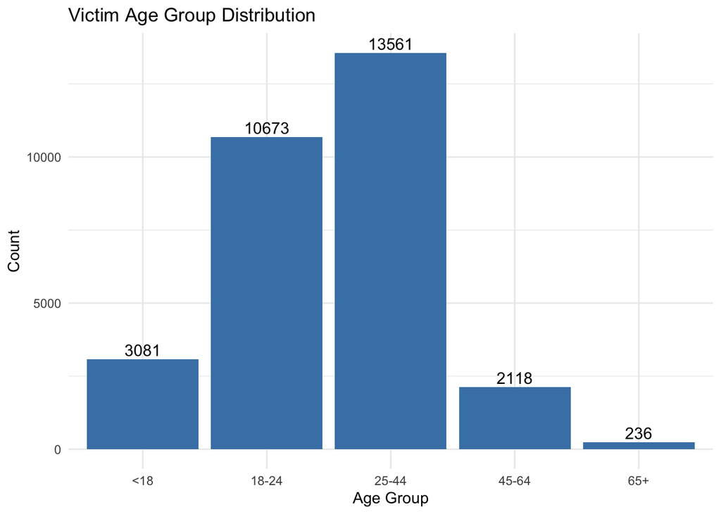

```r
ggplot(victim_filtered_data, aes(x = vic_age_group)) +
  geom_bar(fill = "steelblue") +
  geom_text(stat = "count", aes(label = ..count..), vjust = -0.3, size = 4) +
  labs(
    title = "Victim Age Group Distribution",
    x = "Age Group",
    y = "Count"
  ) +
  theme_minimal()
```

### Gender Distribution

**Pie chart** for victim gender

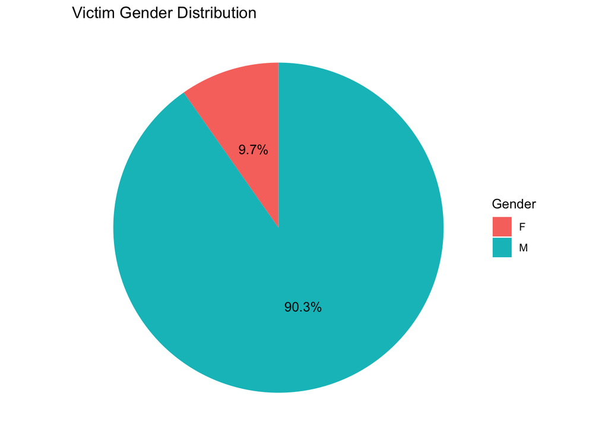

```r
# Summarize counts and compute percentages
gender_counts <- victim_filtered_data %>%
  count(vic_sex) %>%
  mutate(percent = round(n / sum(n) * 100, 1),
         label = paste0(percent, "%"))

# Plot
ggplot(gender_counts, aes(x = "", y = n, fill = vic_sex)) +
  geom_col(width = 1) +
  coord_polar(theta = "y") +
  geom_text(aes(label = label), position = position_stack(vjust = 0.5)) +
  labs(
    title = "Victim Gender Distribution",
    fill = "Gender"
  ) +
  theme_void()
```

## Step 4: Time series Model

### Data preparation

We’ll create a daily dataset to analyze temporal patterns.

```r
# STEP 1: Drop missing dates and select distinct incident per date
incident_counts <- cleaned_data %>%
  filter(!is.na(occur_date)) %>%
  distinct(incident_key, occur_date) %>%  # only unique incidents
  count(occur_date)  # count how many unique incidents per day

# STEP 2: Generate complete date range
min_date <- min(incident_counts$occur_date)
max_date <- max(incident_counts$occur_date)

full_dates <- tibble(occur_date = seq.Date(from = min_date, to = max_date, by = "day"))

# STEP 3: Fill in missing dates with zero incidents
incident_daily <- full_dates %>%
  left_join(incident_counts, by = "occur_date") %>%
  mutate(n = replace_na(n, 0),
         day_of_week = wday(occur_date, label = TRUE))

# Preview the result
head(incident_daily)
```

```
## # A tibble: 6 × 3
##   occur_date     n day_of_week
##   <date>     <int> <ord>
## 1 2006-01-01     7 Sun
## 2 2006-01-02     3 Mon
## 3 2006-01-03     4 Tue
## 4 2006-01-04     4 Wed
## 5 2006-01-05     4 Thu
## 6 2006-01-06     3 Fri
```

### Day Of Week Pattern Analysis

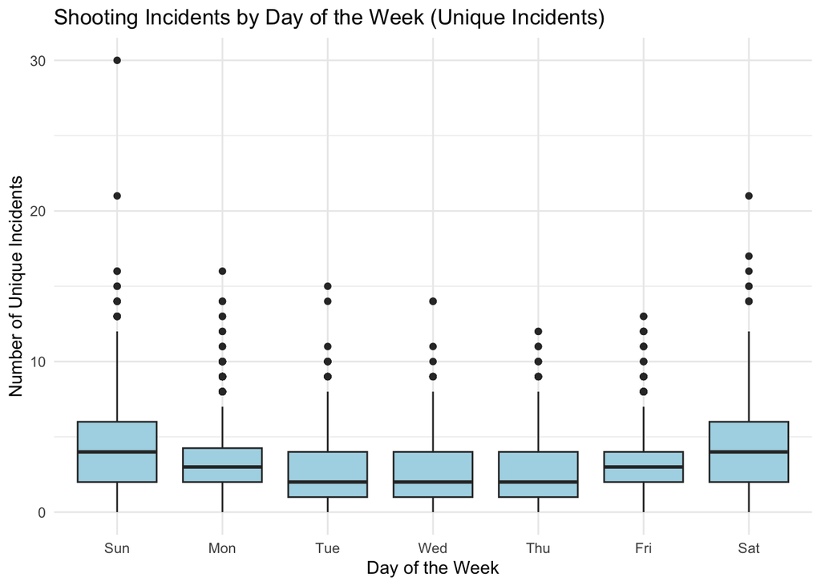

```r
ggplot(incident_daily, aes(x = day_of_week, y = n)) +
  geom_boxplot(fill = "lightblue") +
  labs(
    title = "Shooting Incidents by Day of the Week (Unique Incidents)",
    x = "Day of the Week",
    y = "Number of Unique Incidents"
  ) +
  theme_minimal()
```

The boxplot reveals higher incidence rates on weekends compared to weekdays. Let’s test if it is a significant difference.

### Statistical Significance Test

```r
# One-way ANOVA: Does day of week affect number of incidents?
anova_result <- aov(n ~ day_of_week, data = incident_daily)
summary(anova_result)
```

```
##               Df Sum Sq Mean Sq F value Pr(>F)
## day_of_week    6   3934   655.6   117.1 <2e-16 ***
## Residuals   6933  38808     5.6
## ---
## Signif. codes:  0 '***' 0.001 '**' 0.01 '*' 0.05 '.' 0.1 ' ' 1
```

The p-value is less than 0.05, we can conclude that the day of the week has a **significant** effect on the probability of an incident occurring.

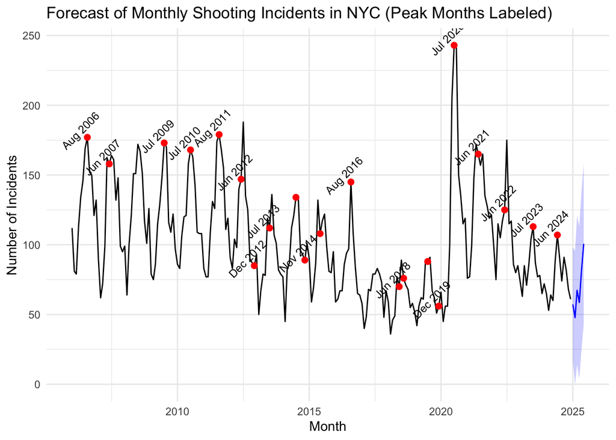

```r
library(forecast)
library(ggplot2)
library(dplyr)
library(lubridate)
library(zoo)

# Step 1: Aggregate by month
monthly_incidents <- incident_daily %>%
  mutate(month = floor_date(occur_date, "month")) %>%
  group_by(month) %>%
  summarise(incidents = sum(n), .groups = "drop") %>%
  arrange(month)

# Step 2: Create monthly time series object
incident_ts_monthly <- ts(monthly_incidents$incidents,
                          start = c(year(min(monthly_incidents$month)), month(min(monthly_incidents$month))),
                          frequency = 12)  # 12 months per year

# Step 3: Fit ARIMA and forecast
model_monthly <- auto.arima(incident_ts_monthly, seasonal = TRUE)
forecast_monthly <- forecast(model_monthly, h = 6)

# Step 4: Detect peaks using rolling average
monthly_incidents <- monthly_incidents %>%
  mutate(roll_mean = rollmean(incidents, 3, fill = NA, align = "center"),
         is_peak = if_else(
           !is.na(roll_mean) &
             lag(roll_mean, 1) < roll_mean &
             lead(roll_mean, 1) < roll_mean,
           TRUE, FALSE),
         label = if_else(is_peak, format(month, "%b %Y"), NA_character_))

# Step 5: Prepare forecast as data frame
forecast_df <- data.frame(
  month = seq(max(monthly_incidents$month) + months(1), by = "month", length.out = 6),
  forecast = as.numeric(forecast_monthly$mean),
  lower = as.numeric(forecast_monthly$lower[, 2]),
  upper = as.numeric(forecast_monthly$upper[, 2])
)

# Step 6: Plot
ggplot() +
  geom_line(data = monthly_incidents, aes(x = month, y = incidents), color = "black") +
  geom_line(data = forecast_df, aes(x = month, y = forecast), color = "blue") +
  geom_ribbon(data = forecast_df, aes(x = month, ymin = lower, ymax = upper), alpha = 0.2, fill = "blue") +
  geom_point(data = monthly_incidents %>% filter(is_peak), aes(x = month, y = incidents), color = "red", size = 2) +
  geom_text(data = monthly_incidents %>% filter(is_peak),
            aes(x = month, y = incidents, label = label),
            vjust = -0.7, angle = 45, size = 3.2, check_overlap = TRUE) +
  labs(title = "Forecast of Monthly Shooting Incidents in NYC (Peak Months Labeled)",
       x = "Month", y = "Number of Incidents") +
  theme_minimal()
```

## Summary

### Potential Bias Consideration

- Data quality issues with unknown/missing demographic information.
- Reporting bias may exist within certain areas or neighborhoods.
- Historical data may not consider policy or social changes over the years.
- The model assumes that past patterns will continue regardless of unaccounted-for future unknown external factors.

This analysis can help create preventive measures to control shooting incidents in NYC.